# Quantify Activity via KNN

Flora Xu

7/9/2017

## Summary

This project is to predict the manner in which the 6 participants did the exercise. We fit the numeric data measured on the belt, forearm, arm, and dumbbell from the training set of 19,622 samples using k-nearest neigours with 10-fold cross-validated, and make prediction on the testing data.

## Data

We download the data and store training and testing data into local files `pml-training.csv` and `pml-testing.csv` respectively.

```r
download.file(url = "https://d396qusza40orc.cloudfront.net/predmachlearn/pml-training.csv",
              destfile = train.file, method = "curl", quiet = T)
download.file(url = "https://d396qusza40orc.cloudfront.net/predmachlearn/pml-testing.csv",
              destfile = test.file, method = "curl", quiet = T)
```

After the downloading, we load the training data into R and get ready for a bit exploration and preparation.

```r
training <- read.csv(train.file, as.is = T)
```

### Data Preparation

The response variable `classe` is ordinal and we first convert the data into factors with given levels.

```r
training$classe <- factor(training$classe, levels = c("A", "B", "C", "D", "E"))
```

Notice that there are quite a few variables that its marjority is missing or empty, we choose to remove these columns.

```r
missing.col <- which(sapply(training,
                      FUN = function(c){sum(is.na(c))})/nrow(training)> .9 )
empty.col <- which(sapply(training, FUN = function(c){sum(c == "")}) > 0)

red.training <- training[, -c(missing.col, empty.col)]
```

Further, we would like to use those measurements on the belt, arm, forearm, and dumbbell as predictors.

```r
## keep those with belt, arm, forearm, dumbell
tokeep <- unique(unlist(sapply(c("belt", "arm", "forearm", "dumbbell"),
                 FUN = function(pattern){grep(pattern = pattern, names(red.training))})))
red.training <- red.training[, c(tokeep, 60)]
```

We shall take a peek at the relationship among some variables, for example roll_belt and roll_forearm and the response variable.

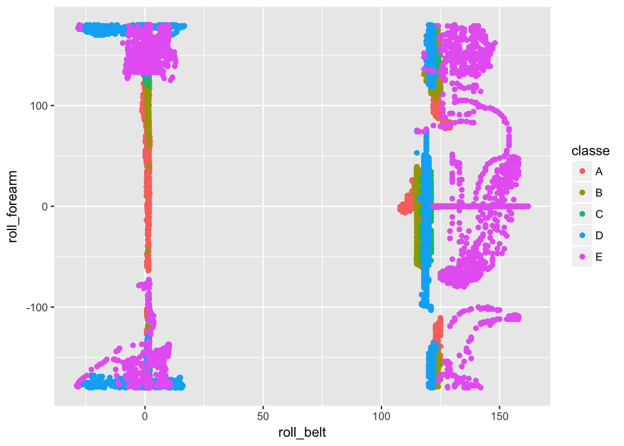

```r
qplot(roll_belt, roll_forearm, colour = classe, data = red.training)
```

We can see some clustering within the roll_belt and roll_forearm.

## Fitting The Data

As the response data is categorical, we can try k-nearest neighours algorithm to fit the data; that is, treating it as a classificatio problem: given the predictors, the model needs to determine which category does the record falls on, either A or B or C or D or E.

We set up a 10-fold cross validation in training the model.

```r
train_control <- trainControl(method="cv", number=10)

set.seed(234)
fit <- train(classe ~ .,
             data = red.training,
             method = "knn",
             preProcess = c("center", "scale"),
             tuneLength = 20,
             trControl = train_control)
```

```r
print(fit)
```

```
## k-Nearest Neighbors
##
## 19622 samples
##    52 predictor
##     5 classes: 'A', 'B', 'C', 'D', 'E'
##
## Pre-processing: centered (52), scaled (52)
## Resampling: Cross-Validated (10 fold)
## Summary of sample sizes: 17661, 17660, 17659, 17662, 17659, 17661, ...
## Resampling results across tuning parameters:
##
##   k   Accuracy   Kappa
##    5  0.9768619  0.9707274
##    7  0.9685037  0.9601493
##    9  0.9595857  0.9488599
##   11  0.9506164  0.9374957
##   13  0.9419527  0.9265226
##   15  0.9337477  0.9161339
##   17  0.9256444  0.9058632
##   19  0.9197834  0.8984463
##   21  0.9122924  0.8889626
##   23  0.9060751  0.8810864
##   25  0.9005198  0.8740523
##   27  0.8938439  0.8656146
##   29  0.8883398  0.8586588
##   31  0.8821736  0.8508281
##   33  0.8761600  0.8432194
##   35  0.8703497  0.8358539
##   37  0.8655594  0.8297913
##   39  0.8614305  0.8245694
##   41  0.8576595  0.8198058
##   43  0.8527670  0.8136096
##
## Accuracy was used to select the optimal model using  the largest value.
## The final value used for the model was k = 5.
```

As the final model chose has an accurary .9768619. The fit is fairly good. We believe that random forest will improve the accuracy, yet, we will leave it here as the rf will take much longer time to run.

### Error

The expected out-of-sample error will be a bit higher than the in-sample error.

```r
pred.classe <- predict(fit, newdata = red.training)
confusionMatrix(pred.classe, red.training$classe)
```

```
## Confusion Matrix and Statistics
##
##           Reference
## Prediction    A    B    C    D    E
##          A 5569   26    3    2    1
##          B    8 3747    7    1    5
##          C    1   20 3399   39    6
##          D    1    3   13 3169    3
##          E    1    1    0    5 3592
##
## Overall Statistics
##
##                Accuracy : 0.9926
##                  95% CI : (0.9913, 0.9937)
##     No Information Rate : 0.2844
##     P-Value [Acc > NIR] : < 2.2e-16
##
##                   Kappa : 0.9906
##  Mcnemar's Test P-Value : 1.507e-05
##
## Statistics by Class:
##
##                      Class: A Class: B Class: C Class: D Class: E
## Sensitivity            0.9980   0.9868   0.9933   0.9854   0.9958
## Specificity            0.9977   0.9987   0.9959   0.9988   0.9996
## Pos Pred Value         0.9943   0.9944   0.9810   0.9937   0.9981
## Neg Pred Value         0.9992   0.9968   0.9986   0.9971   0.9991
## Prevalence             0.2844   0.1935   0.1744   0.1639   0.1838
## Detection Rate         0.2838   0.1910   0.1732   0.1615   0.1831
## Detection Prevalence   0.2854   0.1920   0.1766   0.1625   0.1834
## Balanced Accuracy      0.9979   0.9928   0.9946   0.9921   0.9977
```

### Prediction

We need to load the testing data and remove the same columns as we did on the training data.

```r
testing <- read.csv(test.file, as.is = T)
red.testing <- testing[, -c(missing.col, empty.col)]
red.testing <- red.testing[, c(tokeep)]

data.frame(problem_id = 1:20, classe = predict(fit, red.testing))
```

```
   problem_id classe
1           1      B
2           2      A
3           3      A
4           4      A
5           5      A
6           6      E
7           7      D
8           8      B
9           9      A
10         10      A
11         11      B
12         12      C
13         13      B
14         14      A
15         15      E
16         16      E
17         17      A
18         18      B
19         19      B
20         20      B
```

Using this model, we only made one mistake on problem.id == 3.